# Project Python Foundations: FoodHub Data Analysis

### Context

The number of restaurants in New York is increasing day by day. Lots of students and busy professionals rely on those restaurants due to their hectic lifestyles. Online food delivery service is a great option for them. It provides them with good food from their favorite restaurants. A food aggregator company FoodHub offers access to multiple restaurants through a single smartphone app.

The app allows the restaurants to receive a direct online order from a customer. The app assigns a delivery person from the company to pick up the order after it is confirmed by the restaurant. The delivery person then uses the map to reach the restaurant and waits for the food package. Once the food package is handed over to the delivery person, he/she confirms the pick-up in the app and travels to the customer's location to deliver the food. The delivery person confirms the drop-off in the app after delivering the food package to the customer. The customer can rate the order in the app. The food aggregator earns money by collecting a fixed margin of the delivery order from the restaurants.

### Objective

The food aggregator company has stored the data of the different orders made by the registered customers in their online portal. They want to analyze the data to get a fair idea about the demand of different restaurants which will help them in enhancing their customer experience. Suppose you are hired as a Data Scientist in this company and the Data Science team has shared some of the key questions that need to be answered. Perform the data analysis to find answers to these questions that will help the company to improve the business.

### Data Description

The data contains the different data related to a food order. The detailed data dictionary is given below.

### Data Dictionary

- order_id: Unique ID of the order
- customer_id: ID of the customer who ordered the food
- restaurant_name: Name of the restaurant
- cuisine_type: Cuisine ordered by the customer
- cost_of_the_order: Cost of the order
- day_of_the_week: Indicates whether the order is placed on a weekday or weekend (The weekday is from Monday to Friday and the weekend is Saturday and Sunday)
- rating: Rating given by the customer out of 5
- food_preparation_time: Time (in minutes) taken by the restaurant to prepare the food. This is calculated by taking the difference between the timestamps of the restaurant's order confirmation and the delivery person's pick-up confirmation.
- delivery_time: Time (in minutes) taken by the delivery person to deliver the food package. This is calculated by taking the difference between the timestamps of the delivery person's pick-up confirmation and drop-off information

### Let us start by importing the required libraries

```python
# Installing the libraries with the specified version.
# !pip install numpy==1.25.2 pandas==1.5.3 matplotlib==3.7.1 seaborn==0.13.1 -q --user
```

**Note**: *After running the above cell, kindly restart the notebook kernel and run all cells sequentially from the start again.*

```python
# import libraries for data manipulation
import numpy as np
import pandas as pd

# import libraries for data visualization
import matplotlib.pyplot as plt
import seaborn as sns
```

### Understanding the structure of the data

```python
# uncomment and run the following lines for Google Colab
from google.colab import drive
drive.mount('/content/drive')
```

```python
df = pd.read_csv('/content/drive/MyDrive/Python Course/foodhub_order.csv')
```

```python
df.head()
```

|  | order_id | customer_id | restaurant_name | cuisine_type | cost_of_the_order | day_of_the_week | rating | food_preparation_time | delivery_time |
| --- | --- | --- | --- | --- | --- | --- | --- | --- | --- |
| 0 | 1477147 | 337525 | Hangawi | Korean | 30.75 | Weekend | Not given | 25 | 20 |
| 1 | 1477685 | 358141 | Blue Ribbon Sushi Izakaya | Japanese | 12.08 | Weekend | Not given | 25 | 23 |
| 2 | 1477070 | 66393 | Cafe Habana | Mexican | 12.23 | Weekday | 5 | 23 | 28 |
| 3 | 1477334 | 106968 | Blue Ribbon Fried Chicken | American | 29.20 | Weekend | 3 | 25 | 15 |
| 4 | 1478249 | 76942 | Dirty Bird to Go | American | 11.59 | Weekday | 4 | 25 | 24 |

### **Question 1:** How many rows and columns are present in the data? [0.5 mark]

```python
df.shape
```

```
(1898, 9)
```

#### Observations:

### **Question 2:** What are the datatypes of the different columns in the dataset? (The info() function can be used) [0.5 mark]

```python
df.info()
```

```
<class 'pandas.core.frame.DataFrame'>
RangeIndex: 1898 entries, 0 to 1897
Data columns (total 9 columns):
 #   Column                 Non-Null Count  Dtype
---  ------                 --------------  -----
 0   order_id               1898 non-null   int64
 1   customer_id            1898 non-null   int64
 2   restaurant_name        1898 non-null   object
 3   cuisine_type           1898 non-null   object
 4   cost_of_the_order      1898 non-null   float64
 5   day_of_the_week        1898 non-null   object
 6   rating                 1898 non-null   object
 7   food_preparation_time  1898 non-null   int64
 8   delivery_time          1898 non-null   int64
dtypes: float64(1), int64(4), object(4)
memory usage: 133.6+ KB
```

#### Observations: first, the dataset provided diaplay the first five rows that needed to be analyzed by checking and identifying the data type columns, the dimensions and treating any missing values.

### **Question 3:** Are there any missing values in the data? If yes, treat them using an appropriate method. [1 mark]

```python
df.isnull().sum()
```

|  | 0 |
| --- | --- |
| order_id | 0 |
| customer_id | 0 |
| restaurant_name | 0 |
| cuisine_type | 0 |
| cost_of_the_order | 0 |
| day_of_the_week | 0 |
| rating | 0 |
| food_preparation_time | 0 |
| delivery_time | 0 |

**dtype:** int64

```python
missing_values = df.isnull().sum()
missing_percentage = (missing_values / len(df)) * 100

missing_info = pd.DataFrame({
    'Missing Count': missing_values,
    'Missing Percentage (%)': missing_percentage
})

missing_info
```

|  | Missing Count | Missing Percentage (%) |
| --- | --- | --- |
| order_id | 0 | 0.0 |
| customer_id | 0 | 0.0 |
| restaurant_name | 0 | 0.0 |
| cuisine_type | 0 | 0.0 |
| cost_of_the_order | 0 | 0.0 |
| day_of_the_week | 0 | 0.0 |
| rating | 0 | 0.0 |
| food_preparation_time | 0 | 0.0 |
| delivery_time | 0 | 0.0 |

#### Observations:

- There are no missing values found in the columns.
- These columns missing value count and the percentages are 0 and 0.0%. Apparently, no deletion or imputation is required, and it allowed for quick modeling or analysis.

### **Question 4:** Check the statistical summary of the data. What is the minimum, average, and maximum time it takes for food to be prepared once an order is placed? [2 marks]

```python
df['food_preparation_time'].describe()
```

|  | food_preparation_time |
| --- | --- |
| count | 1898.000000 |
| mean | 27.371970 |
| std | 4.632481 |
| min | 20.000000 |
| 25% | 23.000000 |
| 50% | 27.000000 |
| 75% | 31.000000 |
| max | 35.000000 |

**dtype:** float64

#### Observations: The dataset food preparation times ranges from 20 to 35 minutes, with an average around 27 minutes.

### **Question 5:** How many orders are not rated? [1 mark]

```python
not_rated_orders = df[df['rating'] == 'Not given']
num_not_rated_orders = len(not_rated_orders)
(f"Number of orders not rated: {num_not_rated_orders}")
```

```
'Number of orders not rated: 736'
```

#### Observations: 736 orders seems not to be rated in the dataset.

### Exploratory Data Analysis (EDA)

### **Question 6:** Explore all the variables and provide observations on their distributions. (Generally, histograms, boxplots, countplots, etc. are used for univariate exploration.) [9 marks]

```python
# Displaying the number of unique values in each column
df.nunique()
```

|  | 0 |
| --- | --- |
| order_id | 1898 |
| customer_id | 1200 |
| restaurant_name | 178 |
| cuisine_type | 14 |
| cost_of_the_order | 312 |
| day_of_the_week | 2 |
| rating | 4 |
| food_preparation_time | 16 |
| delivery_time | 19 |

**dtype:** int64

### The dataset provides an insight of the distribution of each variable that consist of visualized numerical variables with histograms, boxplots, and categorical varibles with countplots. however, at the end, key obervation will be taking from univariate analysis.

- First, exploring numerical variables
- Visualize the distributions of numerical variables.Using histograms and boxplots to visualize distribution of numerical variables to understand their central tendency, identify outliers, and spread.

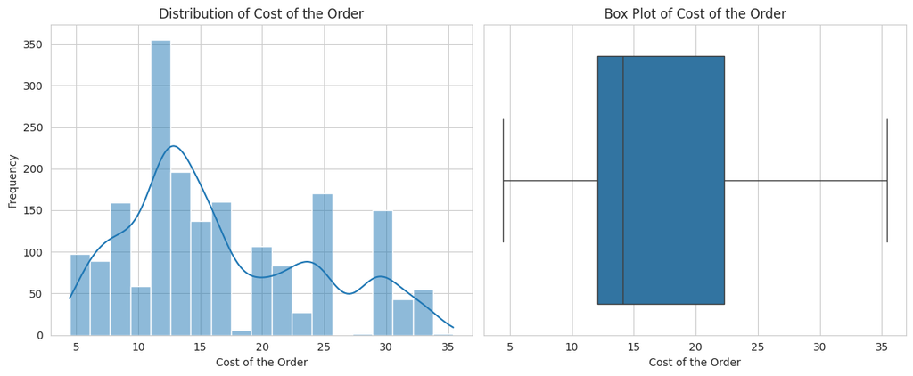

```python
# Aesthetic style of the plots set
sns.set_style("whitegrid")

# Creating subplots for cost_of_the_order
fig, axes = plt.subplots(1, 2, figsize=(12, 5))
sns.histplot(data=df, x='cost_of_the_order', kde=True, ax=axes[0]);
axes[0].set_title('Distribution of Cost of the Order')
axes[0].set_xlabel('Cost of the Order')
axes[0].set_ylabel('Frequency')
sns.boxplot(data=df, x='cost_of_the_order', ax=axes[1]);
axes[1].set_title('Box Plot of Cost of the Order')
axes[1].set_xlabel('Cost of the Order')
plt.tight_layout()
plt.show()
```

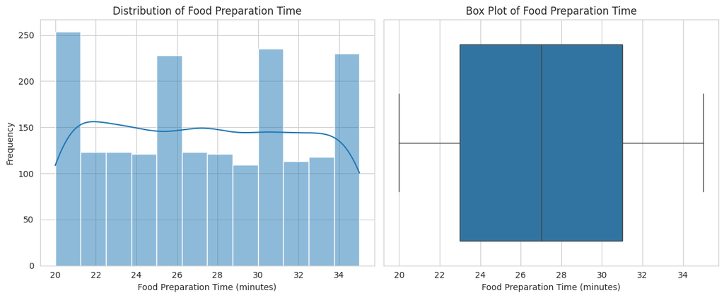

```python
# Creating subplots for food_preparation_time
fig, axes = plt.subplots(1, 2, figsize=(12, 5))
sns.histplot(data=df, x='food_preparation_time', kde=True, ax=axes[0]);
axes[0].set_title('Distribution of Food Preparation Time')
axes[0].set_xlabel('Food Preparation Time (minutes)')
axes[0].set_ylabel('Frequency')
sns.boxplot(data=df, x='food_preparation_time', ax=axes[1]);
axes[1].set_title('Box Plot of Food Preparation Time')
axes[1].set_xlabel('Food Preparation Time (minutes)')
plt.tight_layout()
plt.show()
```

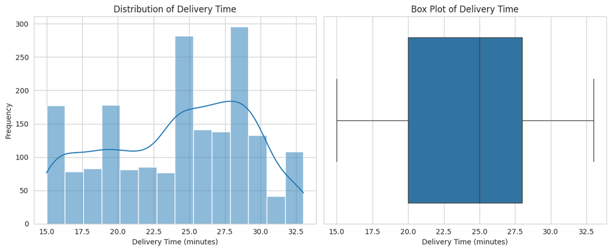

```python
# Creating subplots for delivery_time
fig, axes = plt.subplots(1, 2, figsize=(12, 5))
sns.histplot(data=df, x='delivery_time', kde=True, ax=axes[0]);
axes[0].set_title('Distribution of Delivery Time')
axes[0].set_xlabel('Delivery Time (minutes)')
axes[0].set_ylabel('Frequency')
sns.boxplot(data=df, x='delivery_time', ax=axes[1]);
axes[1].set_title('Box Plot of Delivery Time')
axes[1].set_xlabel('Delivery Time (minutes)')
plt.tight_layout()
plt.show()
```

Exploring categorical variables.

- Visualizing the distributions of categorical variables using countplots to get understanding of the frequency of each category in the data.

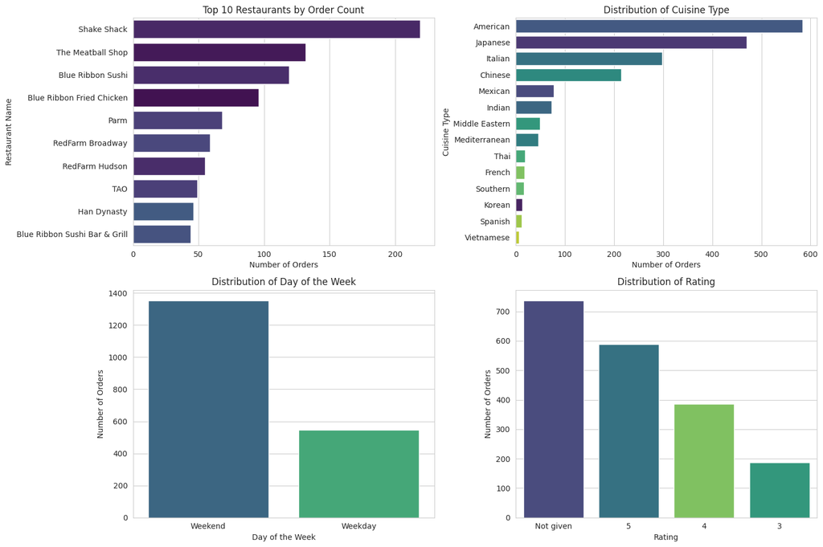

```python
# Creating figures and subplots
fig, axes = plt.subplots(2, 2, figsize=(15, 10))

# Ploting for restaurant_name (Top 10)
sns.countplot(data=df, y='restaurant_name', order=df['restaurant_name'].value_counts().index[:10], ax=axes[0, 0], palette='viridis', hue='restaurant_name', legend=False);
axes[0, 0].set_title('Top 10 Restaurants by Order Count')
axes[0, 0].set_xlabel('Number of Orders')
axes[0, 0].set_ylabel('Restaurant Name')


# Plotting for cuisine_type
sns.countplot(data=df, y='cuisine_type', order=df['cuisine_type'].value_counts().index, ax=axes[0, 1], palette='viridis', hue='cuisine_type', legend=False);
axes[0, 1].set_title('Distribution of Cuisine Type')
axes[0, 1].set_xlabel('Number of Orders')
axes[0, 1].set_ylabel('Cuisine Type')


# Plotting for day_of_the_week
sns.countplot(data=df, x='day_of_the_week', order=df['day_of_the_week'].value_counts().index, ax=axes[1, 0], palette='viridis', hue='day_of_the_week', legend=False);
axes[1, 0].set_title('Distribution of Day of the Week')
axes[1, 0].set_xlabel('Day of the Week')
axes[1, 0].set_ylabel('Number of Orders')

# Plotting for rating
sns.countplot(data=df, x='rating', order=df['rating'].value_counts().index, ax=axes[1, 1], palette='viridis', hue='rating', legend=False);
axes[1, 1].set_title('Distribution of Rating')
axes[1, 1].set_xlabel('Rating')
axes[1, 1].set_ylabel('Number of Orders')


plt.tight_layout()
plt.show()
```

Analysis of Key Observations

### **Question 7**: Which are the top 5 restaurants in terms of the number of orders received? [1 mark]

```python
top_restaurants = df['restaurant_name'].value_counts().head(5)
top_restaurants
```

| restaurant_name | count |
| --- | --- |
| Shake Shack | 219 |
| The Meatball Shop | 132 |
| Blue Ribbon Sushi | 119 |
| Blue Ribbon Fried Chicken | 96 |
| Parm | 68 |

**dtype:** int64

#### Observations:

Shake Shack has the highest orders in the dataset than the other restaurants.

### **Question 8**: Which is the most popular cuisine on weekends? [1 mark]

```python
weekend_data = df[df['day_of_the_week'] == 'Weekend']
most_popular_cuisine_weekend = weekend_data['cuisine_type'].value_counts().head(1)
most_popular_cuisine_weekend
```

| cuisine_type | count |
| --- | --- |
| American | 415 |

**dtype:** int64

#### Observations:

The most popular cuisine on weekends is American with 415 orders.

### **Question 9**: What percentage of the orders cost more than 20 dollars? [2 marks]

```python
orders_cost_more_than_20 = df[df['cost_of_the_order'] > 20]
percentage_more_than_20 = (len(orders_cost_more_than_20) / len(df)) * 100
f"Percentage of orders costing more than 20 dollars: {percentage_more_than_20:.2f}%"
```

```
'Percentage of orders costing more than 20 dollars: 29.24%'
```

#### Observations:

The percentage orders costing more than 20 dollars is 29.24%

### **Question 10**: What is the mean order delivery time? [1 mark]

```python
mean_delivery_time = df['delivery_time'].mean()
f"The mean order delivery time is: {mean_delivery_time:.2f} minutes"
```

```
'The mean order delivery time is: 24.16 minutes'
```

#### Observations:

The mean delivery time is 24.16 minutes

### **Question 11:** The company has decided to give 20% discount vouchers to the top 3 most frequent customers. Find the IDs of these customers and the number of orders they placed. [1 mark]

```python
top_customers = df['customer_id'].value_counts().head(3)
top_customers
```

| customer_id | count |
| --- | --- |
| 52832 | 13 |
| 47440 | 10 |
| 83287 | 9 |

**dtype:** int64

#### Observations:

The highest number of orders are the most frequent customers in the dataset.

### Multivariate Analysis

Exploring relationships between numerical variables by using a correlation matrix and scatter plots.

### **Question 12**: Perform a multivariate analysis to explore relationships between the important variables in the dataset. (It is a good idea to explore relations between numerical variables as well as relations between numerical and categorical variables) [10 marks]

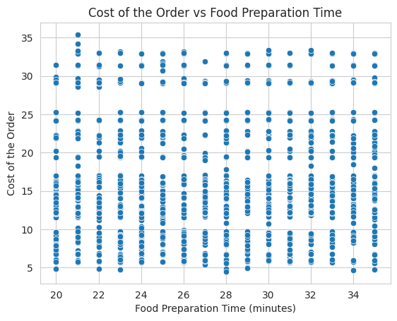

```python
# Creating scatter plots generation
sns.scatterplot(data=df, x='food_preparation_time', y='cost_of_the_order');
plt.title('Cost of the Order vs Food Preparation Time')
plt.xlabel('Food Preparation Time (minutes)')
plt.ylabel('Cost of the Order')
plt.show()
```

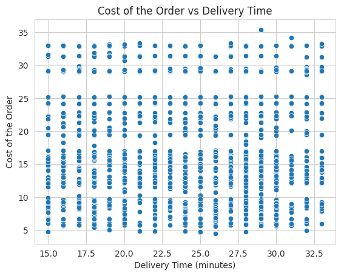

```python
sns.scatterplot(data=df, x='delivery_time', y='cost_of_the_order');
plt.title('Cost of the Order vs Delivery Time')
plt.xlabel('Delivery Time (minutes)')
plt.ylabel('Cost of the Order')
plt.show()
```

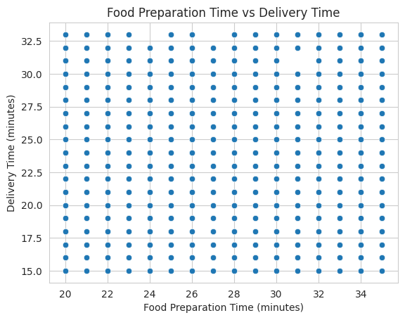

```python
sns.scatterplot(data=df, x='food_preparation_time', y='delivery_time');
plt.title('Food Preparation Time vs Delivery Time')
plt.xlabel('Food Preparation Time (minutes)')
plt.ylabel('Delivery Time (minutes)')
plt.show()
```

```python
# Computing and displaying the correlation matrix
numerical_data = df[['cost_of_the_order', 'food_preparation_time', 'delivery_time']]
correlation_matrix = numerical_data.corr()
correlation_matrix
```

|  | cost_of_the_order | food_preparation_time | delivery_time |
| --- | --- | --- | --- |
| cost_of_the_order | 1.000000 | 0.041527 | -0.029949 |
| food_preparation_time | 0.041527 | 1.000000 | 0.011094 |
| delivery_time | -0.029949 | 0.011094 | 1.000000 |

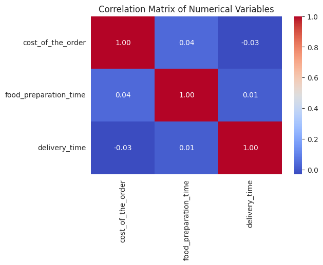

```python
plt.figure(figsize=(6, 4))
sns.heatmap(correlation_matrix, annot=True, cmap='coolwarm', fmt=".2f");
plt.title('Correlation Matrix of Numerical Variables')
plt.show()
```

Exploring the relationships between numerical ariables and categorical variables using violinplots or boxplots.

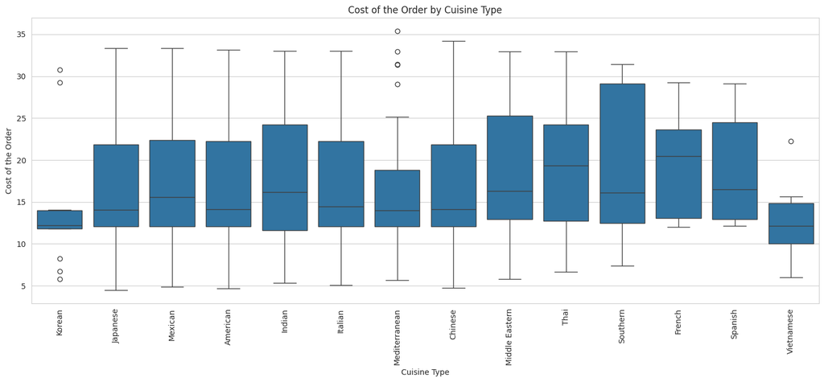

```python
# Creating boxplots for cost_of_the_order by cuisine_type
plt.figure(figsize=(15, 7))
sns.boxplot(data=df, x='cuisine_type', y='cost_of_the_order');
plt.title('Cost of the Order by Cuisine Type')
plt.xlabel('Cuisine Type')
plt.ylabel('Cost of the Order')
plt.xticks(rotation=90)
plt.tight_layout()
plt.show()
```

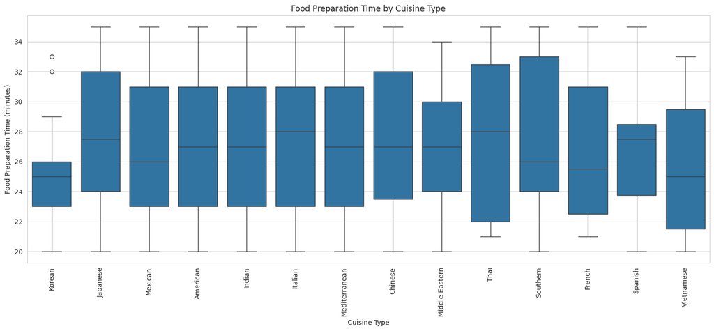

```python
# Creating boxplots for food_preparation_time by cuisine_type
plt.figure(figsize=(15, 7))
sns.boxplot(data=df, x='cuisine_type', y='food_preparation_time');
plt.title('Food Preparation Time by Cuisine Type')
plt.xlabel('Cuisine Type')
plt.ylabel('Food Preparation Time (minutes)')
plt.xticks(rotation=90)
plt.tight_layout()
plt.show()
```

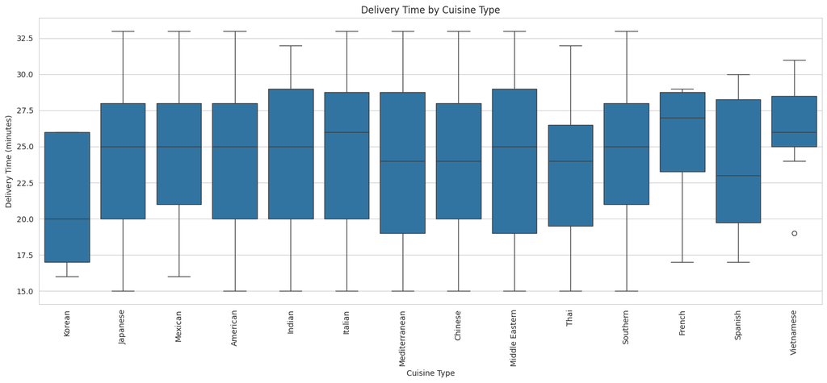

```python
# Create box plots for delivery_time by cuisine_type
plt.figure(figsize=(15, 7))
sns.boxplot(data=df, x='cuisine_type', y='delivery_time');
plt.title('Delivery Time by Cuisine Type')
plt.xlabel('Cuisine Type')
plt.ylabel('Delivery Time (minutes)')
plt.xticks(rotation=90)
plt.tight_layout()
plt.show()
```

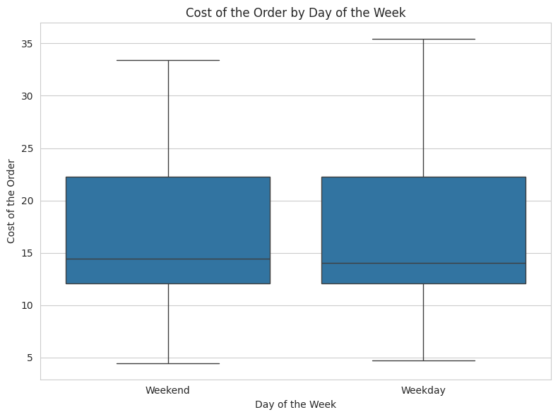

```python
# Creating boxplots for cost_of_the_order by day_of_the_week
plt.figure(figsize=(8, 6))
sns.boxplot(data=df, x='day_of_the_week', y='cost_of_the_order');
plt.title('Cost of the Order by Day of the Week')
plt.xlabel('Day of the Week')
plt.ylabel('Cost of the Order')
plt.tight_layout()
plt.show()
```

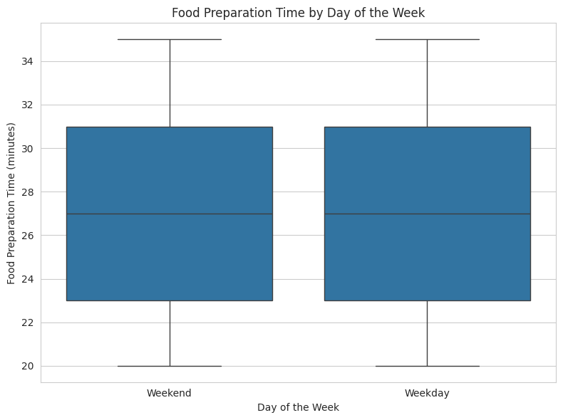

```python
# Creating boxplots for food_preparation_time by day_of_the_week
plt.figure(figsize=(8, 6))
sns.boxplot(data=df, x='day_of_the_week', y='food_preparation_time');
plt.title('Food Preparation Time by Day of the Week')
plt.xlabel('Day of the Week')
plt.ylabel('Food Preparation Time (minutes)')
plt.tight_layout()
plt.show()
```

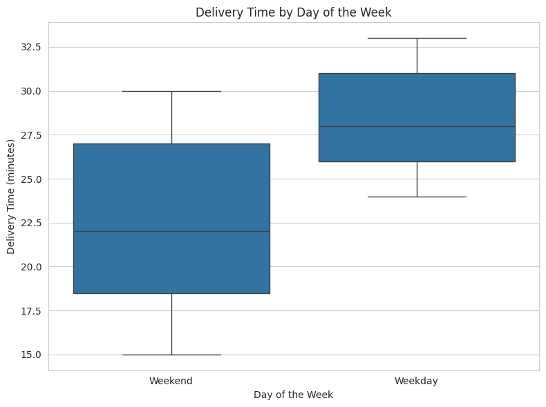

```python
# Creating boxplots for delivery_time by day_of_the_week
plt.figure(figsize=(8, 6))
sns.boxplot(data=df, x='day_of_the_week', y='delivery_time');
plt.title('Delivery Time by Day of the Week')
plt.xlabel('Day of the Week')
plt.ylabel('Delivery Time (minutes)')
plt.tight_layout()
plt.show()
```

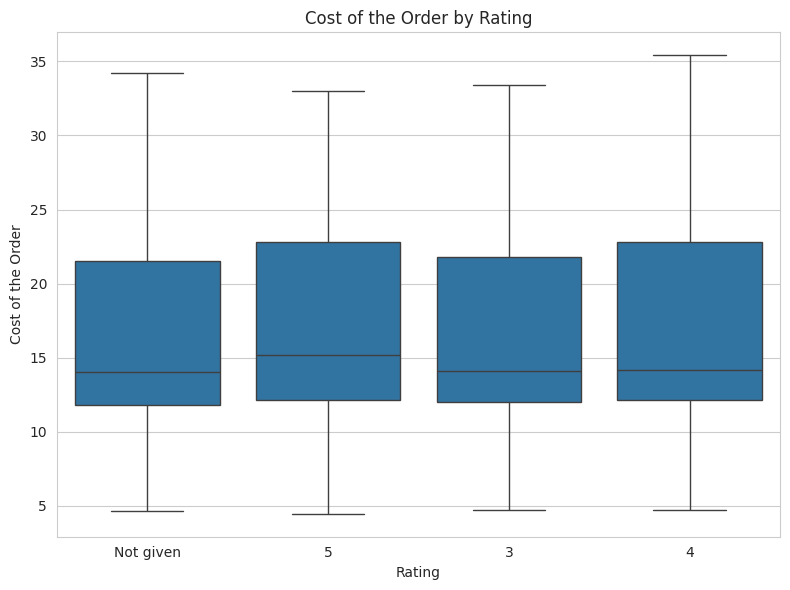

```python
# Creating boxplots for cost_of_the_order by rating
plt.figure(figsize=(8, 6))
sns.boxplot(data=df, x='rating', y='cost_of_the_order');
plt.title('Cost of the Order by Rating')
plt.xlabel('Rating')
plt.ylabel('Cost of the Order')
plt.tight_layout()
plt.show()
```

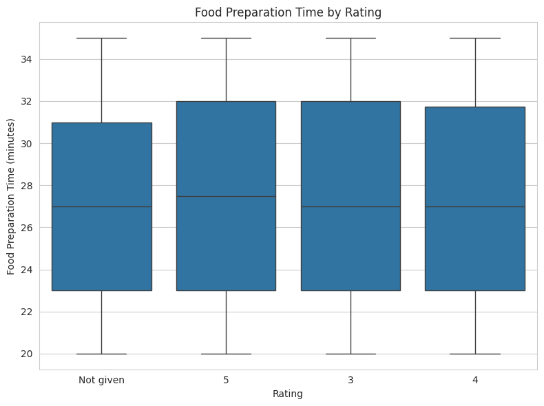

```python
# Creating boxplots for food_preparation_time by rating
plt.figure(figsize=(8, 6))
sns.boxplot(data=df, x='rating', y='food_preparation_time');
plt.title('Food Preparation Time by Rating')
plt.xlabel('Rating')
plt.ylabel('Food Preparation Time (minutes)')
plt.tight_layout()
plt.show()
```

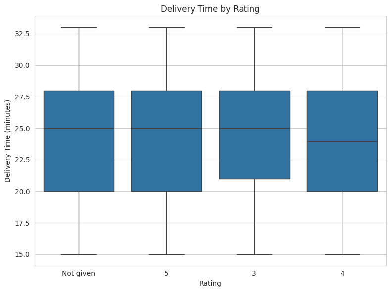

```python
# Creating boxplots for delivery_time by rating
plt.figure(figsize=(8, 6))
sns.boxplot(data=df, x='rating', y='delivery_time');
plt.title('Delivery Time by Rating')
plt.xlabel('Rating')
plt.ylabel('Delivery Time (minutes)')
plt.tight_layout()
plt.show()
```

Analying Key Observations

- The findings show very weak direction in relationship between the numerical variables which are 'cost_of_the_order', 'food_preparation_time', and 'delivery_time', and was indicated by correlation coefficients close to zero.
- Boxplots visualization generated the relationships that were seen between numerical variables which are ('cost_of_the_order', 'food_preparation_time', and 'delivery_time') and categorical variables ('day_of_the_week' and 'rating').
- Disribution of these plots show how the numerical variables varies across different categories.

```python
# Computing the total revenue for each restaurant
restaurant_revenue = df.groupby(['restaurant_name'])['cost_of_the_order'].sum().sort_values(ascending = False).head(14)

restaurant_revenue
```

| restaurant_name | cost_of_the_order |
| --- | --- |
| Shake Shack | 3579.53 |
| The Meatball Shop | 2145.21 |
| Blue Ribbon Sushi | 1903.95 |
| Blue Ribbon Fried Chicken | 1662.29 |
| Parm | 1112.76 |
| RedFarm Broadway | 965.13 |
| RedFarm Hudson | 921.21 |
| TAO | 834.50 |
| Han Dynasty | 755.29 |
| Blue Ribbon Sushi Bar & Grill | 666.62 |
| Rubirosa | 660.45 |
| Sushi of Gari 46 | 640.87 |
| Nobu Next Door | 623.67 |
| Five Guys Burgers and Fries | 506.47 |

**dtype:** float64

The results show the total revenue that was generated by the top 14 restaurants.

- Shake Shack generates the highest total revenue with a significant margin in the data.
- Five Guys Burgers and Fries generates the lower total revenue.
- A few of the top restaurants contribute larger portion of the total revenue.
- There was s drop in revenue between the top restaurants and the ones down the list.

### **Question 13:** The company wants to provide a promotional offer in the advertisement of the restaurants. The condition to get the offer is that the restaurants must have a rating count of more than 50 and the average rating should be greater than 4. Find the restaurants fulfilling the criteria to get the promotional offer. [3 marks]

Filtering out 'not given' ratings:

Excluding orders with 'Not given' ratings from the analysis.

```python
# Filtering out the rows where rating are 'Not given'
rated_df = df[df['rating'] != 'Not given'].copy()

rated_df.head()
```

|  | order_id | customer_id | restaurant_name | cuisine_type | cost_of_the_order | day_of_the_week | rating | food_preparation_time | delivery_time |
| --- | --- | --- | --- | --- | --- | --- | --- | --- | --- |
| 2 | 1477070 | 66393 | Cafe Habana | Mexican | 12.23 | Weekday | 5 | 23 | 28 |
| 3 | 1477334 | 106968 | Blue Ribbon Fried Chicken | American | 29.20 | Weekend | 3 | 25 | 15 |
| 4 | 1478249 | 76942 | Dirty Bird to Go | American | 11.59 | Weekday | 4 | 25 | 24 |
| 5 | 1477224 | 147468 | Tamarind TriBeCa | Indian | 25.22 | Weekday | 3 | 20 | 24 |
| 7 | 1477859 | 89574 | Barbounia | Mediterranean | 5.97 | Weekday | 3 | 33 | 30 |

```python
# Converting the 'rating' column to numerical data type
rated_df['rating'] = rated_df['rating'].astype(float)

rated_df.info()
```

```
<class 'pandas.core.frame.DataFrame'>
Index: 1162 entries, 2 to 1896
Data columns (total 9 columns):
 #   Column                 Non-Null Count  Dtype
---  ------                 --------------  -----
 0   order_id               1162 non-null   int64
 1   customer_id            1162 non-null   int64
 2   restaurant_name        1162 non-null   object
 3   cuisine_type           1162 non-null   object
 4   cost_of_the_order      1162 non-null   float64
 5   day_of_the_week        1162 non-null   object
 6   rating                 1162 non-null   float64
 7   food_preparation_time  1162 non-null   int64
 8   delivery_time          1162 non-null   int64
dtypes: float64(2), int64(4), object(3)
memory usage: 90.8+ KB
```

```python
# Converting the 'rating' column to numerical data type
rated_df['rating'] = rated_df['rating'].astype(float)

# Group by restaurant in the data and calculate the count and average of ratings
restaurant_ratings = rated_df.groupby('restaurant_name')['rating'].agg(['count', 'mean']).reset_index()

# The columns rename for clarity
restaurant_ratings.rename(columns={'count': 'rating_count', 'mean': 'average_rating'}, inplace=True)

restaurant_ratings.head()
```

|  | restaurant_name | rating_count | average_rating |
| --- | --- | --- | --- |
| 0 | 'wichcraft | 1 | 5.0 |
| 1 | 12 Chairs | 2 | 4.5 |
| 2 | 5 Napkin Burger | 2 | 4.0 |
| 3 | 67 Burger | 1 | 5.0 |
| 4 | Amma | 2 | 4.5 |

```python
# Filtering for restaurants with more than 50 ratings in the data
high_rating_count_restaurants = restaurant_ratings[restaurant_ratings['rating_count'] > 50]

# More filtering for restaurants with an average rating greater than 4 in the data
qualifying_restaurants = high_rating_count_restaurants[high_rating_count_restaurants['average_rating'] > 4]

qualifying_restaurants
```

|  | restaurant_name | rating_count | average_rating |
| --- | --- | --- | --- |
| 16 | Blue Ribbon Fried Chicken | 64 | 4.328125 |
| 17 | Blue Ribbon Sushi | 73 | 4.219178 |
| 117 | Shake Shack | 133 | 4.278195 |
| 132 | The Meatball Shop | 84 | 4.511905 |

```python
# Showing the restaurants that fulfill the criteria for the promotional offer.
qualifying_restaurants
```

|  | restaurant_name | rating_count | average_rating |
| --- | --- | --- | --- |
| 16 | Blue Ribbon Fried Chicken | 64 | 4.328125 |
| 17 | Blue Ribbon Sushi | 73 | 4.219178 |
| 117 | Shake Shack | 133 | 4.278195 |
| 132 | The Meatball Shop | 84 | 4.511905 |

#### Observations:

- Blue Ribbon Fried Chicken, Blue Ribbon Sushi, Shake Shack, and The Meatball Shop are the restaurants that met the rating count greater than 50 and average rating greater than 4.
- These four specific restaurants could be a target for special promotional offers because of their high volume of ratings and positive feedback.

### **Question 14:** The company charges the restaurant 25% on the orders having cost greater than 20 dollars and 15% on the orders having cost greater than 5 dollars. Find the net revenue generated by the company across all orders. [3 marks]

```python
def calculate_commission(cost):
    """
    Calculates the commission for an order based on its cost.

    Args:
        cost (float): The cost of the order.

    Returns:
        float: The calculated commission.
    """
    if cost > 20:
        return cost * 0.25
    elif cost > 5:
        return cost * 0.15
    else:
        return 0
```

```python
# Applying the calculate_commission function to create the 'commission' column
df['commission'] = df['cost_of_the_order'].apply(calculate_commission)

df.head()
```

|  | order_id | customer_id | restaurant_name | cuisine_type | cost_of_the_order | day_of_the_week | rating | food_preparation_time | delivery_time | commission |
| --- | --- | --- | --- | --- | --- | --- | --- | --- | --- | --- |
| 0 | 1477147 | 337525 | Hangawi | Korean | 30.75 | Weekend | Not given | 25 | 20 | 7.6875 |
| 1 | 1477685 | 358141 | Blue Ribbon Sushi Izakaya | Japanese | 12.08 | Weekend | Not given | 25 | 23 | 1.8120 |
| 2 | 1477070 | 66393 | Cafe Habana | Mexican | 12.23 | Weekday | 5 | 23 | 28 | 1.8345 |
| 3 | 1477334 | 106968 | Blue Ribbon Fried Chicken | American | 29.20 | Weekend | 3 | 25 | 15 | 7.3000 |
| 4 | 1478249 | 76942 | Dirty Bird to Go | American | 11.59 | Weekday | 4 | 25 | 24 | 1.7385 |

```python
# Calculating the total net revenue
net_revenue = df['commission'].sum()

f"Total Net Revenue: ${net_revenue:.2f}"
```

```
'Total Net Revenue: $6166.30'
```

```python
f"Total Net Revenue: ${net_revenue:.2f}"
```

```
'Total Net Revenue: $6166.30'
```

#### Observations:

- The commission was calculated based on the cost: 25% for orders costing more than $20 and 15% for orders costing more than $5.
- According to the result of the output, the total net revenue generated by the company across all orders is $6166.30.

### **Question 15:** The company wants to analyze the total time required to deliver the food. What percentage of orders take more than 60 minutes to get delivered from the time the order is placed? (The food has to be prepared and then delivered.) [2 marks]

```python
df['total_delivery_time'] = df['food_preparation_time'] + df['delivery_time']

df.head()
```

|  | order_id | customer_id | restaurant_name | cuisine_type | cost_of_the_order | day_of_the_week | rating | food_preparation_time | delivery_time | commission | total_delivery_time |
| --- | --- | --- | --- | --- | --- | --- | --- | --- | --- | --- | --- |
| 0 | 1477147 | 337525 | Hangawi | Korean | 30.75 | Weekend | Not given | 25 | 20 | 7.6875 | 45 |
| 1 | 1477685 | 358141 | Blue Ribbon Sushi Izakaya | Japanese | 12.08 | Weekend | Not given | 25 | 23 | 1.8120 | 48 |
| 2 | 1477070 | 66393 | Cafe Habana | Mexican | 12.23 | Weekday | 5 | 23 | 28 | 1.8345 | 51 |
| 3 | 1477334 | 106968 | Blue Ribbon Fried Chicken | American | 29.20 | Weekend | 3 | 25 | 15 | 7.3000 | 40 |
| 4 | 1478249 | 76942 | Dirty Bird to Go | American | 11.59 | Weekday | 4 | 25 | 24 | 1.7385 | 49 |

```python
# Calculating the number of orders that took more than 60 minutes
orders_over_60_minutes = df[df['total_delivery_time'] > 60].shape[0]

# Calculating the percentage of orders that took more than 60 minutes
percentage_over_60_minutes = (orders_over_60_minutes / df.shape[0]) * 100

f"Percentage of orders taking more than 60 minutes to deliver: {percentage_over_60_minutes:.2f}%"
```

```
'Percentage of orders taking more than 60 minutes to deliver: 10.54%'
```

#### Observations:

- total_delivery_time, was added as a new column, representing the sum of food_preparation_time and delivery_time.
- 10.54% of orders had a total delivery time exceeding 60 minutes.

### **Question 16:** The company wants to analyze the delivery time of the orders on weekdays and weekends. How does the mean delivery time vary during weekdays and weekends? [2 marks]

```python
mean_delivery_time_by_day = df.groupby('day_of_the_week')['delivery_time'].mean()

mean_delivery_time_by_day
```

| day_of_the_week | delivery_time |
| --- | --- |
| Weekday | 28.340037 |
| Weekend | 22.470022 |

**dtype:** float64

#### Observations:

The mean delivery time on weekdays is approximately 28.34 minutes, while on weekends it is approximately 22.47 minutes. However, it shows that the average delivery time is longer during weekdays compared to weekends

### Recommendations:

- Marketing campaigns can be tool for designing or highlighting the most popular cuisines. These restaurants can take advantage on the demand.
- Leverage most be Targeted towards popular cuisine types and top-performing restaurants to attract more customers and increase order volume. For example, American on weekends with special promotional offers. Restaurants with high average ratings and high rating counts like The Meatball Shop, Shake Shack, Blue Ribbon Sushi, and Blue Ribbon Fried Chicken qualify for such offers.
- Implementing strategies to Improve rating Participation by encourage customers to rate their orders. They can provide incentives such as small discounts for future order and a loyalty program for rewarding active reviewers.
- Analyzing and investigating the factors that might be contributing to longer delivery times and food preparation. For example, this could be delay of preparation time or logistics delivery.
- You can Set Service Level Agreements (SLAs) to optimize food preparation times and delivery to improve efficiency and customer satisfaction.
- Investigate the high-cost orders to understand customer behavior and look for opportunities to introduce some promotions or premium services.
- Share insights by utilizing feedbacks for Improvemen from customer ratings. and also feedbacks from restaurants to help them improve their service quality, food preparation, and service delivery. Restaurants with high ratings, can identify their best practices models and share them with others.

With optimization, and driving business growth, FoodHub can Improve customer experience, by implementing these recommendations.